# Exploitation Rate Creel Titration

Colin Dassow

2023-11-29

# 1 WDNR Creel Titration

## 1.1 **Purpose**

The term ‘titration’ is used here to describe the main question this analysis seeks to answer:

> **How much less creel data could be collected, on an individual survey basis while still maintaining the stratified random sampling design, and still produce exploitation rate ($u$) estimates that are NOT significantly different from exploitation rates obtained using the current creel survey design?**

The data informing these analyses has all been pulled from the Fisheries Management Information System (FMIS) using the `wdnr.fmdb` `R` package built to interface with this database. All analyses were conducted in `R` using R version 4.3.1 (2023-06-16 ucrt).

## 1.2 Current Creel Data as Baseline

DNR has amassed a large amount of inland creel information over many decades (1984-2023) across many waterbodies (n=314). Using this data and functionality of `wdnr.fmdb` it is possible to calculate effort, catch, harvest, and harvest rate for multiple species for each unique creel survey conducted. This information can be further grouped by month, season, day type, etc. to provide insight into important temporal patterns in the fisheries metrics of interest. These calculations are accomplished fairly easily using the following code:

```r
# reading in DNR creel data

cserv = get_creel_surveys()
cvis = get_creel_visits()
ccou = get_creel_counts()
cint = get_creel_int_party()
cfish = get_creel_fish_data()
```

```r
ceff = calc_creel_effort(creel_count_data = ccou, creel_int_data = cint)

charv = calc_creel_harvest(creel_count_data = ccou, creel_int_data = cint,
    creel_fish_data = cfish)

charvR = calc_creel_harvest_rates(creel_fish_data = cfish)
```

## 1.3 Walleye Exploitation Rate *u*

Here I’m dealing specifically with walleye exploitation rate estimates for ceded territory lakes only. Exploitation rate is a key metric under the Voigt Decision and any proposed changes to creel surveys would need to ensure that the proper exploitation rate information can still be gathered.

What I’ve done here is calculate exploitation rates based on the full data sets as well as for 5 scenarios:

1. all winter creel information removed
2. only creel information from ‘summer’ May to August is used
3. 25% of weekday creel visits per month are removed
4. 50% of weekday creel visits per month are removed
5. 50% of weekend creel visits per month are removed. Creel visits are removed on a month by month basis by randomly removing creel visits to the lake that day

This random removal of days per month and day type should maintain the statistical integrity of the stratified random design that is a part of the creel survey. For context, this was not how data was removed in a similar analysis done by Deroba et al. (2007) where they removed entire weeks (randomly selected) per month instead of randomly selecting days. Their analysis also employed t-tests to analyze the resulting exploitation rates in each of their reduced data sets which relies on the assumption of normality and has been discussed above.

Exploitation rate ($u$) was calculated as:

$$u=\frac{R}{M}$$
$$R=(\frac{C}{T})H$$

Where $R$ is the estimated total number of marked fish harvested for a given creel strata and $M$ is the total number of walleye marked that spring during fyke net surveys. The estimate of the number of marked fish harvested per strata ($R$) is obtained by applying the proportion of marked fish observed in the creel to the total harvest estimate for that strata ($H$). $C$ is the actual number of marked fish observed in a given creel strata and $T$ is the total number of fish examined.

When calculating $u$ for each data set I first calculated $u$ by each month and day type then calculated an average $u$ for that creel survey based on `survey.seq.no` to produce one exploitation rate for that survey. This was done to match the exploitation rate database which provides exploitation rates on a survey-level and not the strata-level.

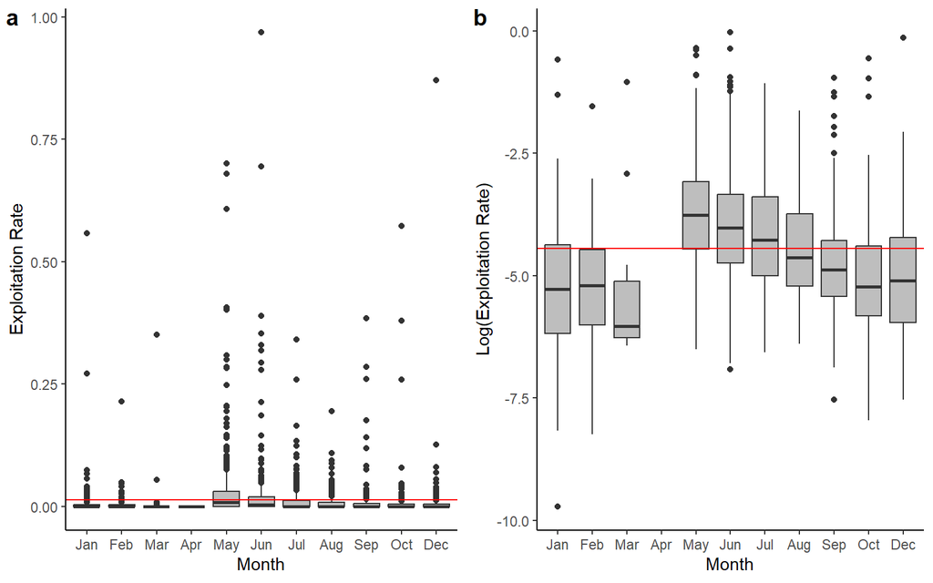

Distribution of exploitation rates by month (panel a) for all years of CTWI creel data. Horizontal red line is overall mean exploitation rate. Black points are outliers. Panel B is the same information presented on a log-scale. In both plots exploitation rates of 0 are omitted.

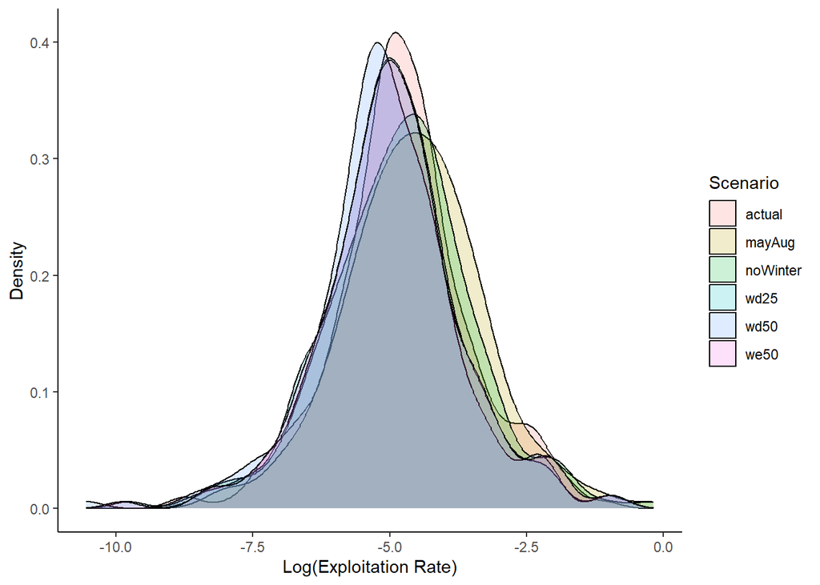

Distribution, on a log scale, of exploitation rates for the full data set plus 5 scenarios with reduced data. Actual = full data set, mayAug = May to August creel data only, noWinter = winter creel data removed, wd25 = 25% of weekday creel visits per month removed, wd50 = 50% of weekday creel visits per month removed, we50 = 50% of weekend creel visits per month removed.

### 1.3.1 Bayesian Model Fitting

In order to estimate parameters for a model of the exploitation rate distribution that produced what is represented in the creel data a Bayesian modeling approach was used. This is because the exploitation rate data are not normally distributed and thus don’t meet the assumptions of typical analyses based on normality. Here I’ve chosen to model the data with a lognormal distribution, other potential options for the type of data are the gamma and beta distributions. A Bayesian approach also allows for the inclusion of prior information about the system and does not rely on p-values (though some Bayesian p-values are presented later on) which are arbitrary in nature and can be manipulated via high sample sizes. The Bayesian approach can be adapted to accommodate and prior distribution we feel is necessary be it lognormal, beta, or gamma.

Individual likelihoods were constructed for each reduced data set and fit using the functions in the `BayesianTools` package in `R`. These model fits were checked for convergence using visual inspection of trace plots, posterior distributions, and Gelman-Rubin Diagnostic tests to ensure that models had converged. All models were fit using Differential Evolution Markov-Chain-Monte-Carlo algorithms run for 10,000 iterations with the first 5,000 discarded as burn-in.

```r
# one likelihood to estimate parms for using the 6
# different treatments creating data frame to model with u
# rates that are NA removed, these are 6% of the data and
# are from years where creel happened but no fish were FN
# marked concurrently.
modDat = ttrExp[!is.na(ttrExp$exp.rate), ]

# removing 0s since they can't be logged and if I were to
# make them a small number they would throw off the data
# and make it bimodal which would probably mean switching
# to a gamma or beta distribution to model the data. Could
# work, but I don't have time to mess with that right now.
# I'm going to operate under the assumption that if a
# survey give a 0 exploitation rate with the full survey,
# then us collecting less data isn't going to change that
# number.
zeros.actual = sum(modDat$exp.rate[modDat$treat == "actual"] ==
    0)
zeros.nw = sum(modDat$exp.rate[modDat$treat == "noWinter"] ==
    0)
zeros.ma = sum(modDat$exp.rate[modDat$treat == "mayAug"] == 0)
zeros.wd25 = sum(modDat$exp.rate[modDat$treat == "wd25"] == 0)
zeros.wd50 = sum(modDat$exp.rate[modDat$treat == "wd50"] == 0)
zeros.we50 = sum(modDat$exp.rate[modDat$treat == "we50"] == 0)

Ztab = data.frame(Scenario = c("Actual", "No Winter", "May-August",
    "25% Weekday Reduction", "50% Weekday Reduction", "50% Weekend Reduction"),
    Zeros = c(zeros.actual, zeros.nw, zeros.ma, zeros.wd25, zeros.wd50,
        zeros.we50))
kable(Ztab, format = "latex", caption = "Table of the number of surveys with exploitation rate estimates equal to 0 for each data scenario.")
```

[output not shown]

```r
# removing 0s here as described in the text.
modDat = modDat[modDat$exp.rate != 0, ]

#### ACTUAL ####
uLL.a = function(param) {
    alpha = param[1]
    beta = param[2]

    us = rlnorm(nrow(modDat[modDat$treat == "actual", ]), meanlog = alpha,
        sdlog = beta)
    ll = dlnorm(modDat$exp.rate[modDat$treat == "actual"], meanlog = mean(log(us)),
        sdlog = sd(log(us)), log = T)
    return(sum(ll))
}

prior = createTruncatedNormalPrior(mean = c(mean(log(modDat$exp.rate[modDat$treat ==
    "actual"])), sd(log(modDat$exp.rate[modDat$treat == "actual"]))),
    sd = c(1, 1), lower = c(-15, 0), upper = c(15, 5))

setup.actual = createBayesianSetup(uLL.a, prior = prior)

settings = list(iterations = 10000, nrChains = 3, message = F,
    burnin = 5000)
set.seed(10)
expR.actual = runMCMC(bayesianSetup = setup.actual, sampler = "DEzs",
    settings = settings)


#### NW ####
uLL.nw = function(param) {
    alpha = param[1]
    beta = param[2]

    us = rlnorm(nrow(modDat[modDat$treat == "noWinter", ]), meanlog = alpha,
        sdlog = beta)
    ll = dlnorm(modDat$exp.rate[modDat$treat == "noWinter"],
        meanlog = mean(log(us)), sdlog = sd(log(us)), log = T)
    return(sum(ll))
}

prior = createTruncatedNormalPrior(mean = c(mean(log(modDat$exp.rate[modDat$treat ==
    "noWinter"])), sd(log(modDat$exp.rate[modDat$treat == "noWinter"]))),
    sd = c(1, 1), lower = c(-15, 0), upper = c(15, 5))

setup.nw = createBayesianSetup(uLL.nw, prior = prior)

settings = list(iterations = 10000, nrChains = 3, message = F,
    burnin = 5000)
set.seed(10)
expR.nw = runMCMC(bayesianSetup = setup.nw, sampler = "DEzs",
    settings = settings)

#### MA ####

uLL.ma = function(param) {
    alpha = param[1]
    beta = param[2]

    us = rlnorm(nrow(modDat[modDat$treat == "mayAug", ]), meanlog = alpha,
        sdlog = beta)
    ll = dlnorm(modDat$exp.rate[modDat$treat == "mayAug"], meanlog = mean(log(us)),
        sdlog = sd(log(us)), log = T)
    return(sum(ll))
}

prior = createTruncatedNormalPrior(mean = c(mean(log(modDat$exp.rate[modDat$treat ==
    "mayAug"])), sd(log(modDat$exp.rate[modDat$treat == "mayAug"]))),
    sd = c(1, 1), lower = c(-15, 0), upper = c(15, 5))

setup.ma = createBayesianSetup(uLL.ma, prior = prior)

settings = list(iterations = 10000, nrChains = 3, message = F,
    burnin = 5000)
set.seed(10)
expR.ma = runMCMC(bayesianSetup = setup.ma, sampler = "DEzs",
    settings = settings)

#### WD25 ####

uLL.wd25 = function(param) {
    alpha = param[1]
    beta = param[2]

    us = rlnorm(nrow(modDat[modDat$treat == "wd25", ]), meanlog = alpha,
        sdlog = beta)
    ll = dlnorm(modDat$exp.rate[modDat$treat == "wd25"], meanlog = mean(log(us)),
        sdlog = sd(log(us)), log = T)
    return(sum(ll))
}

prior = createTruncatedNormalPrior(mean = c(mean(log(modDat$exp.rate[modDat$treat ==
    "wd25"])), sd(log(modDat$exp.rate[modDat$treat == "wd25"]))),
    sd = c(1, 1), lower = c(-15, 0), upper = c(15, 5))

setup.wd25 = createBayesianSetup(uLL.wd25, prior = prior)

settings = list(iterations = 10000, nrChains = 3, message = F,
    burnin = 5000)
set.seed(10)
expR.25wd = runMCMC(bayesianSetup = setup.wd25, sampler = "DEzs",
    settings = settings)

#### WD50 ####
uLL.wd50 = function(param) {
    alpha = param[1]
    beta = param[2]

    us = rlnorm(nrow(modDat[modDat$treat == "wd50", ]), meanlog = alpha,
        sdlog = beta)
    ll = dlnorm(modDat$exp.rate[modDat$treat == "wd50"], meanlog = mean(log(us)),
        sdlog = sd(log(us)), log = T)
    return(sum(ll))
}

prior = createTruncatedNormalPrior(mean = c(mean(log(modDat$exp.rate[modDat$treat ==
    "wd50"])), sd(log(modDat$exp.rate[modDat$treat == "wd50"]))),
    sd = c(1, 1), lower = c(-15, 0), upper = c(15, 5))

setup.wd50 = createBayesianSetup(uLL.wd50, prior = prior)

settings = list(iterations = 10000, nrChains = 3, message = F,
    burnin = 5000)
set.seed(10)
expR.50wd = runMCMC(bayesianSetup = setup.wd50, sampler = "DEzs",
    settings = settings)

#### WE50 ####
uLL.we50 = function(param) {
    alpha = param[1]
    beta = param[2]

    us = rlnorm(nrow(modDat[modDat$treat == "we50", ]), meanlog = alpha,
        sdlog = beta)
    ll = dlnorm(modDat$exp.rate[modDat$treat == "we50"], meanlog = mean(log(us)),
        sdlog = sd(log(us)), log = T)
    return(sum(ll))
}

prior = createTruncatedNormalPrior(mean = c(mean(log(modDat$exp.rate[modDat$treat ==
    "we50"])), sd(log(modDat$exp.rate[modDat$treat == "we50"]))),
    sd = c(1, 1), lower = c(-15, 0), upper = c(15, 5))

setup.we50 = createBayesianSetup(uLL.we50, prior = prior)

settings = list(iterations = 10000, nrChains = 3, message = F,
    burnin = 5000)
set.seed(10)
expR.50we = runMCMC(bayesianSetup = setup.we50, sampler = "DEzs",
    settings = settings)
```

### 1.3.2 Model Checking

Gelman-Rubin diagnostics were also used to assess convergence, while this doesn’t assess model fit it does describe whether or not the MCMC algorithm converged on a solution or whether the parameter space has not been fully explored yet. For this test values below 1.1 are considered ‘converged’ with a value of 1 being the lowest possible score. All models had Gelmin-Rubin test values < 1.03.

In this analysis two test statistics have been chosen to provide alternate, but not unrelated, measures of model fit. These are the coefficient of variation and standard deviation. Any test statistic of choice could be chosen as long as it can be justified for the objectives of the analysis at hand.

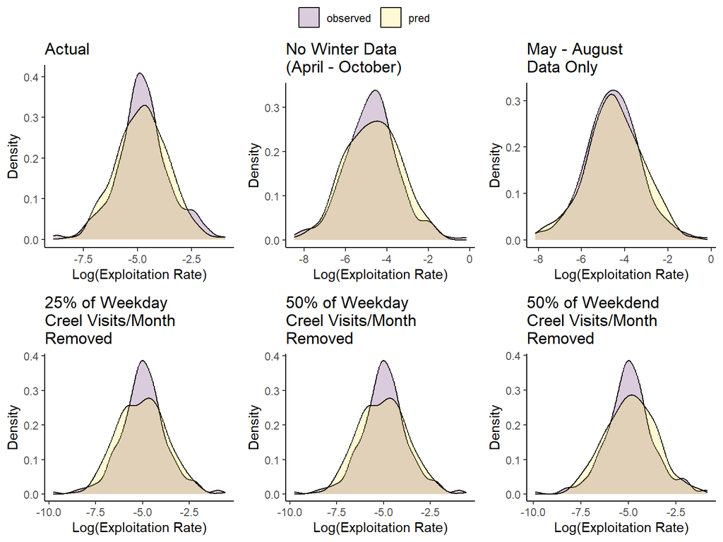

Distributions of the observed and model predicted data for each scenario. Model predicted data comes from lognormal distribution paramterized using the median parmater estimate of the model posterior.

```r
gelmanDiagnostics(expR.actual)  # converged
gelmanDiagnostics(expR.nw)  # converged
gelmanDiagnostics(expR.ma)  # converged
gelmanDiagnostics(expR.25wd)  # converged
gelmanDiagnostics(expR.50wd)  # converged
gelmanDiagnostics(expR.50we)  # converged
```

Bayesian p-values for two variance metrics and each modeled data set.

| scenario | coef.var.pval | sd.pval |
| --- | --- | --- |
| Actual | 0.472 | 0.530 |
| No Winter | 0.477 | 0.533 |
| May-August | 0.465 | 0.539 |
| 25% weeday removal | 0.476 | 0.518 |
| 50% weekday removal | 0.480 | 0.521 |
| 50% weekend removal | 0.482 | 0.529 |

### 1.3.3 Inference

Having established that the models are fitting the data well, some inference can be gained as to whether or not the reductions in creel effort proposed here would result in a meaningful change in the exploitation rates estimated from the data.

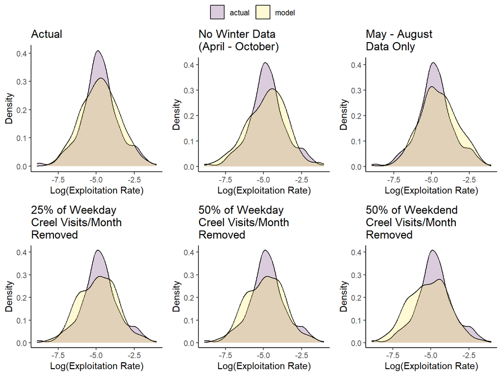

Comparison of the distribution of actual exploitation rates calculated from creel data and exploitation rates calculated from simulated creel data for each data reduction scenario and the resulting median parameter values for their respective model fits.

A Bayesian p-value can be employed here too. A test between the cv and sd of the actual data and the cv and sd of the simulated reduction data can describe whether the model of the reduced data is able to approximate the actual data or not. Successful approximations are p-values close to 0.5 with reduced fit as values increase or decrease beyond 0.5. Generally, the rule of thumb is that p-values $<0.10$ or $>0.90$ signal unacceptable fits.

Bayesian p-values for the comparison between the actual data and the scenario-specific model. This test is asking whether the scenario-specific model can approximate the actual data. When true this signals no effect of the data reduction for that scenario on the resulting exploitation rates.

| scenario | coef.var.pval | sd.pval |
| --- | --- | --- |
| Actual | 0.472 | 0.530 |
| No Winter | 0.217 | 0.795 |
| May-August | 0.138 | 0.738 |
| 25% weeday removal | 0.519 | 0.683 |
| 50% weekday removal | 0.497 | 0.766 |
| 50% weekend removal | 0.405 | 0.771 |

### 1.3.4 Year Specific Analyses

Instead of modeling the full population of exploitation rates as was done above, here I have done the model fitting on individual creel-years so that I can see how the removal of data for a creel-year (which is a comparatively large amount of missing data since on 16=20 lakes are creeled each year) impacts the exploitation rates estimated that year and used to set safe harvest limits. This analysis will follow the same routine as the whole-population analyses above but only consider one creel-year at a time.

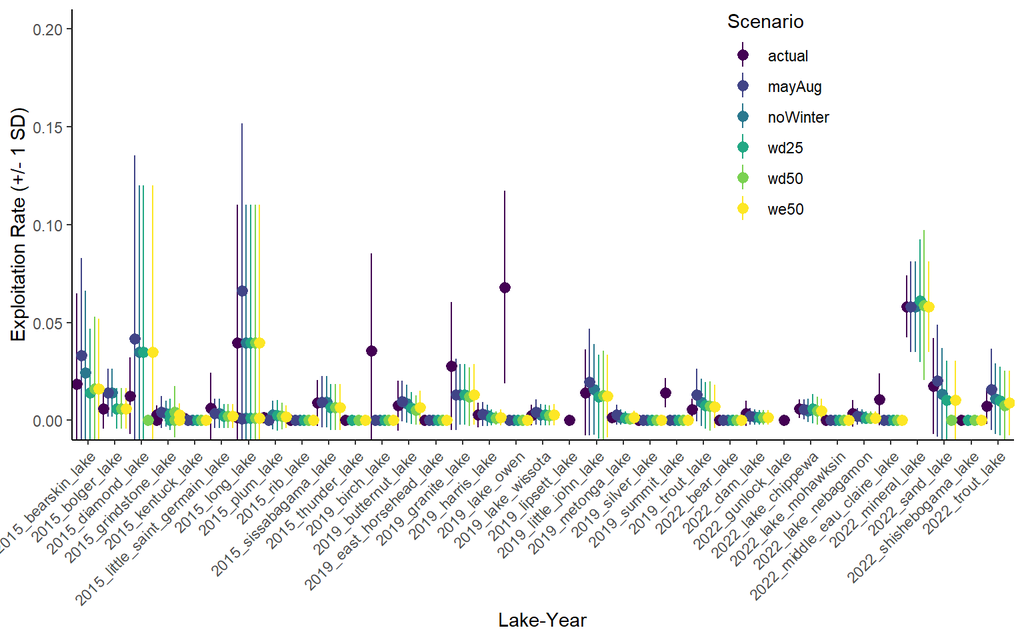

Comparison of the exploitation rates estimated from the reduced data for a handful of creel surveys. Most data reductions do not result in exploitaion rates that are much different from the actual data (most are within 1 SD of the actual). Colors represent data reduction scenarios, points are mean exploitaiton rate estimates across all months of that creel survey and vertical lines represent 1 standard deviation.

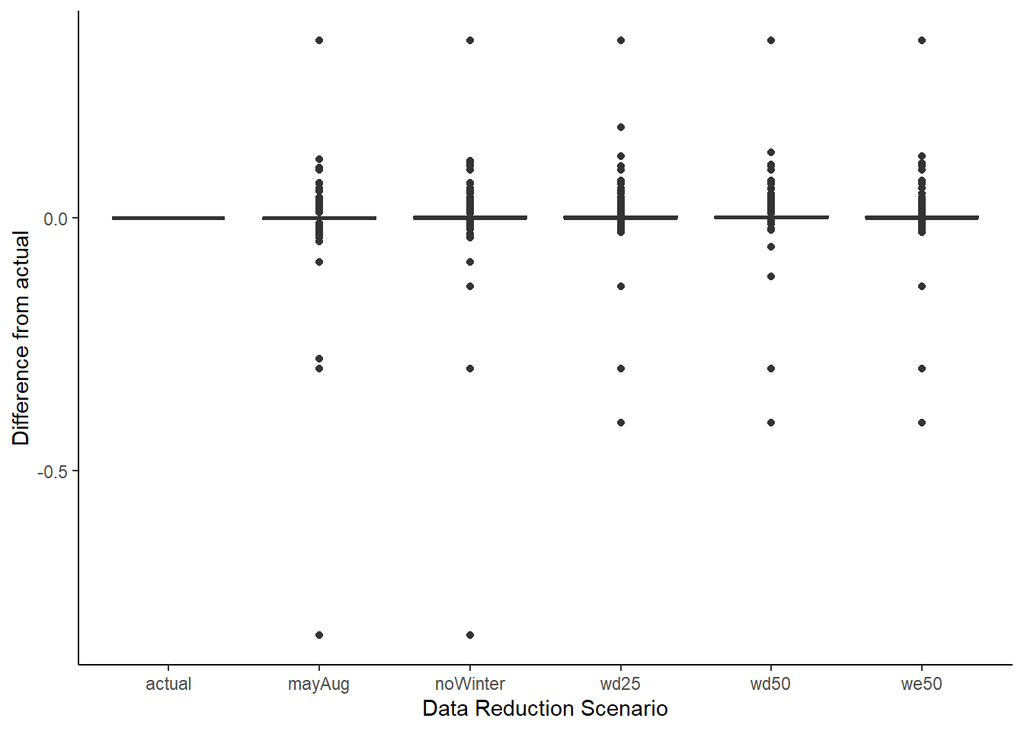

Boxplot of the difference between the actual exploitaiton rate and the data-reduced exploitaion rate for each creel survey in the creel dataset. Most of the data exhibits differences very near 0, dots represent outliers (x<|> x’s percentile-1.5*interquartile range)

Counts of the number of times the exploitation rate estimate for the reduced data scenario differes from the actual exploitaion rate by more than 1 standard deviation. NAs ocurred where there was no variance in the exploitation rate estimate and thus no standard deviation could be calculated for the actual data.

| Data Reduction Scenario | u’s exceeding actual | u’s not exceeding actual | NAs |
| --- | --- | --- | --- |
| actual | 0 | 303 | 45 |
| mayAug | 4 | 284 | 24 |
| noWinter | 3 | 289 | 25 |
| wd25 | 3 | 300 | 35 |
| wd50 | 3 | 300 | 35 |
| we50 | 3 | 300 | 35 |

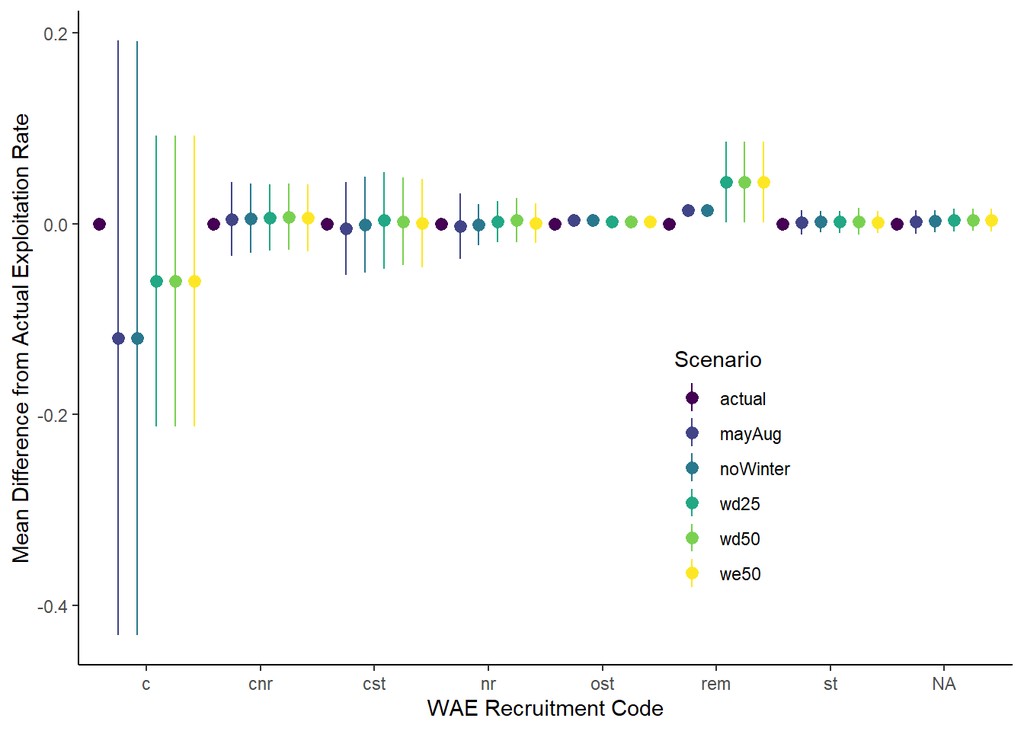

Comparison of the magnitutde of the difference between the mean actual exploitation rate and the estimate derived from each reduced data set. Vertical lines represent 1 standard deviation. Walleye recruitment codes are along the x axis. Note the y-axis scale, many of the differences are small.

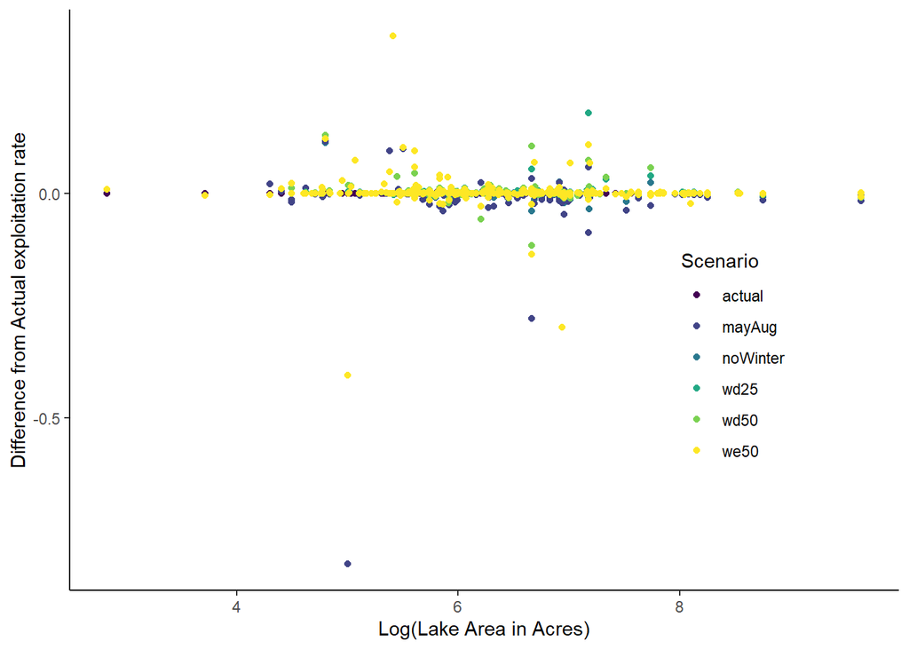

Comparison of the magnitutde of the difference between the mean actual exploitation rate and the estimate derived from each reduced data set. Note the y-axis scale, many of the differences are small.

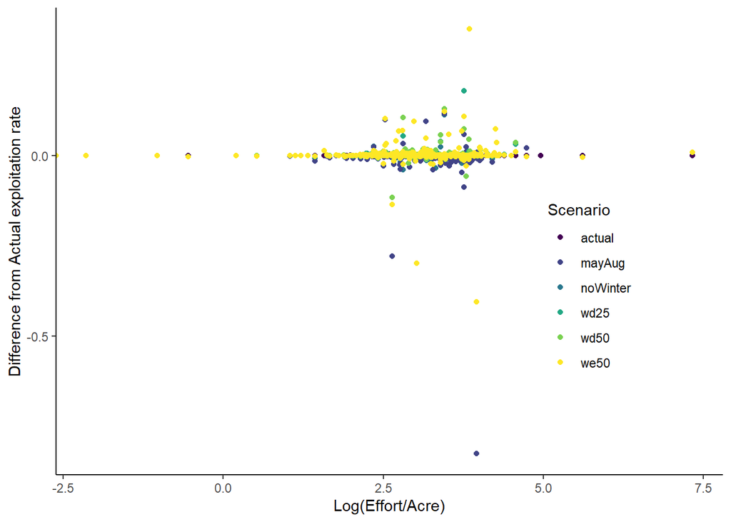

Comparison of the magnitutde of the difference between the mean actual exploitation rate and the estimate derived from each reduced data set. Note the y-axis scale, many of the differences are small.

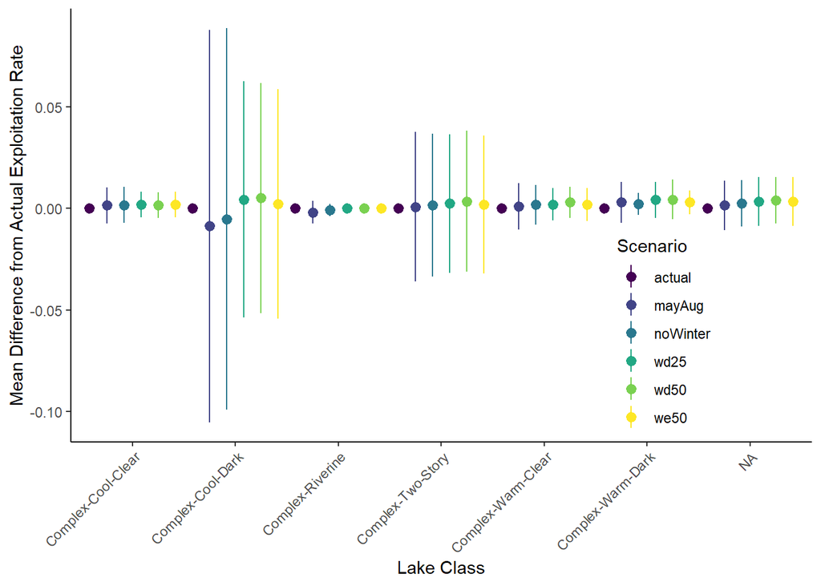

Comparison of the magnitutde of the difference between the mean actual exploitation rate and the estimate derived from each reduced data set. Vertical lines represent 1 standard deviation. Note the y-axis scale, many of the differences are very small.

```r
# MODELING EFFECTS OF DATA REDUCTION ON INDIVIDUAL YEARS

# likelihoods to fit
uLL.we50 = function(param) {
    alpha = param[1]
    beta = param[2]

    us = rlnorm(nrow(tdat[tdat$treat == "we50", ]), meanlog = alpha,
        sdlog = beta)
    ll = dlnorm(tdat$exp.rate[tdat$treat == "we50"], meanlog = mean(log(us)),
        sdlog = sd(log(us)), log = T)
    return(sum(ll))
}
uLL.wd50 = function(param) {
    alpha = param[1]
    beta = param[2]

    us = rlnorm(nrow(tdat[tdat$treat == "wd50", ]), meanlog = alpha,
        sdlog = beta)
    ll = dlnorm(tdat$exp.rate[tdat$treat == "wd50"], meanlog = mean(log(us)),
        sdlog = sd(log(us)), log = T)
    return(sum(ll))
}
uLL.wd25 = function(param) {
    alpha = param[1]
    beta = param[2]

    us = rlnorm(nrow(tdat[tdat$treat == "wd25", ]), meanlog = alpha,
        sdlog = beta)
    ll = dlnorm(tdat$exp.rate[tdat$treat == "wd25"], meanlog = mean(log(us)),
        sdlog = sd(log(us)), log = T)
    return(sum(ll))
}
uLL.ma = function(param) {
    alpha = param[1]
    beta = param[2]

    us = rlnorm(nrow(tdat[tdat$treat == "mayAug", ]), meanlog = alpha,
        sdlog = beta)
    ll = dlnorm(tdat$exp.rate[tdat$treat == "mayAug"], meanlog = mean(log(us)),
        sdlog = sd(log(us)), log = T)
    return(sum(ll))
}
uLL.nw = function(param) {
    alpha = param[1]
    beta = param[2]

    us = rlnorm(nrow(tdat[tdat$treat == "noWinter", ]), meanlog = alpha,
        sdlog = beta)
    ll = dlnorm(tdat$exp.rate[tdat$treat == "noWinter"], meanlog = mean(log(us)),
        sdlog = sd(log(us)), log = T)
    return(sum(ll))
}
uLL.a = function(param) {
    alpha = param[1]
    beta = param[2]

    us = rlnorm(nrow(tdat[tdat$treat == "actual", ]), meanlog = alpha,
        sdlog = beta)
    ll = dlnorm(tdat$exp.rate[tdat$treat == "actual"], meanlog = mean(log(us)),
        sdlog = sd(log(us)), log = T)
    return(sum(ll))
}

# removing 0s
ttrExp = ttrExp[ttrExp$exp.rate != 0, ]
loopY = sort(unique(ttrExp$year))

bpval.comp.y = data.frame(year = NA, scenario = NA, coef.var.pval = NA,
    sd.pval = NA)

bpval.self.y = data.frame(year = NA, scenario = NA, coef.var.pval = NA,
    sd.pval = NA)

for (y in 1:length(loopY)) {
    # first get to year-specific data
    tdat = ttrExp[ttrExp$year == loopY[y], ]
    # removing 0s,
    tdat = tdat[tdat$exp.rate != 0, ]
    # Bayesian Model Fitting ACTUAL

    prior = createTruncatedNormalPrior(mean = c(mean(log(ttrExp$exp.rate[ttrExp$treat ==
        "actual"])), sd(log(ttrExp$exp.rate[ttrExp$treat == "actual"]))),
        sd = c(1, 1), lower = c(-15, 0), upper = c(15, 5))

    setup.a = createBayesianSetup(uLL.a, prior = prior)

    settings = list(iterations = 10000, nrChains = 3, message = F,
        burnin = 5000)
    set.seed(10)
    t.a = runMCMC(bayesianSetup = setup.a, sampler = "DEzs",
        settings = settings)
    # NW

    prior = createTruncatedNormalPrior(mean = c(mean(log(ttrExp$exp.rate[ttrExp$treat ==
        "noWinter"])), sd(log(ttrExp$exp.rate[ttrExp$treat ==
        "noWinter"]))), sd = c(1, 1), lower = c(-15, 0), upper = c(15,
        5))

    setup.nw = createBayesianSetup(uLL.nw, prior = prior)

    settings = list(iterations = 10000, nrChains = 3, message = F,
        burnin = 5000)
    set.seed(10)
    t.nw = runMCMC(bayesianSetup = setup.nw, sampler = "DEzs",
        settings = settings)
    # MA

    prior = createTruncatedNormalPrior(mean = c(mean(log(ttrExp$exp.rate[ttrExp$treat ==
        "mayAug"])), sd(log(ttrExp$exp.rate[ttrExp$treat == "mayAug"]))),
        sd = c(1, 1), lower = c(-15, 0), upper = c(15, 5))

    setup.ma = createBayesianSetup(uLL.ma, prior = prior)

    settings = list(iterations = 10000, nrChains = 3, message = F,
        burnin = 5000)
    set.seed(10)
    t.ma = runMCMC(bayesianSetup = setup.ma, sampler = "DEzs",
        settings = settings)
    # WD.25

    prior = createTruncatedNormalPrior(mean = c(mean(log(ttrExp$exp.rate[ttrExp$treat ==
        "wd25"])), sd(log(ttrExp$exp.rate[ttrExp$treat == "wd25"]))),
        sd = c(1, 1), lower = c(-15, 0), upper = c(15, 5))

    setup.wd25 = createBayesianSetup(uLL.wd25, prior = prior)

    settings = list(iterations = 10000, nrChains = 3, message = F,
        burnin = 5000)
    set.seed(10)
    t.25wd = runMCMC(bayesianSetup = setup.wd25, sampler = "DEzs",
        settings = settings)
    # WD.50

    prior = createTruncatedNormalPrior(mean = c(mean(log(ttrExp$exp.rate[ttrExp$treat ==
        "wd50"])), sd(log(ttrExp$exp.rate[ttrExp$treat == "wd50"]))),
        sd = c(1, 1), lower = c(-15, 0), upper = c(15, 5))

    setup.wd50 = createBayesianSetup(uLL.wd50, prior = prior)

    settings = list(iterations = 10000, nrChains = 3, message = F,
        burnin = 5000)
    set.seed(10)
    t.50wd = runMCMC(bayesianSetup = setup.wd50, sampler = "DEzs",
        settings = settings)

    # WE.50

    prior = createTruncatedNormalPrior(mean = c(mean(log(ttrExp$exp.rate[ttrExp$treat ==
        "we50"])), sd(log(ttrExp$exp.rate[ttrExp$treat == "we50"]))),
        sd = c(1, 1), lower = c(-15, 0), upper = c(15, 5))

    setup.we50 = createBayesianSetup(uLL.we50, prior = prior)

    settings = list(iterations = 10000, nrChains = 3, message = F,
        burnin = 5000)
    set.seed(10)
    t.50we = runMCMC(bayesianSetup = setup.we50, sampler = "DEzs",
        settings = settings)

    ## BAYESIAN P-VALUE CALCS

    pars.a = getSample(t.a)
    pars.nw = getSample(t.nw)
    pars.ma = getSample(t.ma)
    pars.wd25 = getSample(t.25wd)
    pars.wd50 = getSample(t.50wd)
    pars.we50 = getSample(t.50we)

    #### Pb ACTUAL ####
    pval.actual = data.frame(alpha = rep(NA, nrow(pars.a)), beta = NA,
        cv = NA, sd = NA)
    set.seed(10)
    for (i in 1:nrow(pars.a)) {
        tempdat = rlnorm(n = length(tdat$exp.rate[tdat$treat ==
            "actual"]), meanlog = pars.a[i, 1], sdlog = pars.a[i,
            2])
        pval.actual$alpha[i] = pars.a[i, 1]
        pval.actual$beta[i] = pars.a[i, 2]
        pval.actual$cv[i] = sd(log(tempdat))/mean(log(tempdat))
        pval.actual$sd[i] = sd(log(tempdat))
    }
```

```r
    # now calculate the number of times the cv or sd
    # exceeds that of the real data

    pval.actual$cvExceed = 0
    pval.actual$sdExceed = 0

    actual.cv = sd(log(tdat$exp.rate[tdat$treat == "actual"]))/mean(log(tdat$exp.rate[tdat$treat ==
        "actual"]))
    actual.sd = sd(log(tdat$exp.rate[tdat$treat == "actual"]))

    pval.actual$cvExceed[pval.actual$cv > actual.cv] = 1
    pval.actual$sdExceed[pval.actual$sd > actual.sd] = 1

    #### Pb NO WINTER ####
    pval.noWinter = data.frame(alpha = rep(NA, nrow(pars.nw)),
        beta = NA, cv = NA, sd = NA)
    set.seed(10)
    for (i in 1:nrow(pars.nw)) {
        tempdat = rlnorm(n = length(tdat$exp.rate[tdat$treat ==
            "noWinter"]), meanlog = pars.nw[i, 1], sdlog = pars.nw[i,
            2])
        pval.noWinter$alpha[i] = pars.nw[i, 1]
        pval.noWinter$beta[i] = pars.nw[i, 2]
        pval.noWinter$cv[i] = sd(log(tempdat))/mean(log(tempdat))
        pval.noWinter$sd[i] = sd(log(tempdat))
    }

    # now calculate the number of times the cv or sd
    # exceeds that of the real data

    pval.noWinter$cvExceed = 0
    pval.noWinter$sdExceed = 0

    noWinter.cv = sd(log(tdat$exp.rate[tdat$treat == "noWinter"]))/mean(log(tdat$exp.rate[tdat$treat ==
        "noWinter"]))
    noWinter.sd = sd(log(tdat$exp.rate[tdat$treat == "noWinter"]))

    pval.noWinter$cvExceed[pval.noWinter$cv > noWinter.cv] = 1
    pval.noWinter$sdExceed[pval.noWinter$sd > noWinter.sd] = 1

    #### Pb MAYAUGUST ####
    pval.mayAug = data.frame(alpha = rep(NA, nrow(pars.ma)),
        beta = NA, cv = NA, sd = NA)
    set.seed(10)
    for (i in 1:nrow(pars.ma)) {
        tempdat = rlnorm(n = length(tdat$exp.rate[tdat$treat ==
            "mayAug"]), meanlog = pars.ma[i, 1], sdlog = pars.ma[i,
            2])
        pval.mayAug$alpha[i] = pars.ma[i, 1]
        pval.mayAug$beta[i] = pars.ma[i, 2]
        pval.mayAug$cv[i] = sd(log(tempdat))/mean(log(tempdat))
        pval.mayAug$sd[i] = sd(log(tempdat))
    }

    # now calculate the number of times the cv or sd
    # exceeds that of the real data

    pval.mayAug$cvExceed = 0
    pval.mayAug$sdExceed = 0

    mayAug.cv = sd(log(tdat$exp.rate[tdat$treat == "mayAug"]))/mean(log(tdat$exp.rate[tdat$treat ==
        "mayAug"]))
    mayAug.sd = sd(log(tdat$exp.rate[tdat$treat == "mayAug"]))

    pval.mayAug$cvExceed[pval.mayAug$cv > mayAug.cv] = 1
    pval.mayAug$sdExceed[pval.mayAug$sd > mayAug.sd] = 1

    #### Pb WD25 ####
    pval.wd25 = data.frame(alpha = rep(NA, nrow(pars.wd25)),
        beta = NA, cv = NA, sd = NA)
    set.seed(10)
    for (i in 1:nrow(pars.wd25)) {
        tempdat = rlnorm(n = length(tdat$exp.rate[tdat$treat ==
            "wd25"]), meanlog = pars.wd25[i, 1], sdlog = pars.wd25[i,
            2])
        pval.wd25$alpha[i] = pars.wd25[i, 1]
        pval.wd25$beta[i] = pars.wd25[i, 2]
        pval.wd25$cv[i] = sd(log(tempdat))/mean(log(tempdat))
        pval.wd25$sd[i] = sd(log(tempdat))
    }

    # now calculate the number of times the cv or sd
    # exceeds that of the real data

    pval.wd25$cvExceed = 0
    pval.wd25$sdExceed = 0

    wd25.cv = sd(log(tdat$exp.rate[tdat$treat == "wd25"]))/mean(log(tdat$exp.rate[tdat$treat ==
        "wd25"]))
    wd25.sd = sd(log(tdat$exp.rate[tdat$treat == "wd25"]))

    pval.wd25$cvExceed[pval.wd25$cv > wd25.cv] = 1
    pval.wd25$sdExceed[pval.wd25$sd > wd25.sd] = 1

    #### Pb WD50 ####
    pval.wd50 = data.frame(alpha = rep(NA, nrow(pars.wd50)),
        beta = NA, cv = NA, sd = NA)
    set.seed(10)
    for (i in 1:nrow(pars.wd50)) {
        tempdat = rlnorm(n = length(tdat$exp.rate[tdat$treat ==
            "wd50"]), meanlog = pars.wd50[i, 1], sdlog = pars.wd50[i,
            2])
        pval.wd50$alpha[i] = pars.wd50[i, 1]
        pval.wd50$beta[i] = pars.wd50[i, 2]
        pval.wd50$cv[i] = sd(log(tempdat))/mean(log(tempdat))
        pval.wd50$sd[i] = sd(log(tempdat))
    }

    # now calculate the number of times the cv or sd
    # exceeds that of the real data

    pval.wd50$cvExceed = 0
    pval.wd50$sdExceed = 0

    wd50.cv = sd(log(tdat$exp.rate[tdat$treat == "wd50"]))/mean(log(tdat$exp.rate[tdat$treat ==
        "wd50"]))
    wd50.sd = sd(log(tdat$exp.rate[tdat$treat == "wd50"]))

    pval.wd50$cvExceed[pval.wd50$cv > wd50.cv] = 1
    pval.wd50$sdExceed[pval.wd50$sd > wd50.sd] = 1

    #### Pb WE50 ####
    pval.we50 = data.frame(alpha = rep(NA, nrow(pars.we50)),
        beta = NA, cv = NA, sd = NA)
    set.seed(10)
    for (i in 1:nrow(pars.we50)) {
        tempdat = rlnorm(n = length(tdat$exp.rate[tdat$treat ==
            "we50"]), meanlog = pars.we50[i, 1], sdlog = pars.we50[i,
            2])
        pval.we50$alpha[i] = pars.we50[i, 1]
        pval.we50$beta[i] = pars.we50[i, 2]
        pval.we50$cv[i] = sd(log(tempdat))/mean(log(tempdat))
        pval.we50$sd[i] = sd(log(tempdat))
    }

    # now calculate the number of times the cv or sd
    # exceeds that of the real data

    pval.we50$cvExceed = 0
    pval.we50$sdExceed = 0

    we50.cv = sd(log(tdat$exp.rate[tdat$treat == "we50"]))/mean(log(tdat$exp.rate[tdat$treat ==
        "we50"]))
    we50.sd = sd(log(tdat$exp.rate[tdat$treat == "we50"]))

    pval.we50$cvExceed[pval.we50$cv > we50.cv] = 1
    pval.we50$sdExceed[pval.we50$sd > we50.sd] = 1

    # df to hold pvals for model comparison to self, a way
    # of knowing the model fit the data well
    t.pself = data.frame(year = rep(loopY[y], 6), scenario = c("Actual",
        "No Winter", "May-August", "25% weeday removal", "50% weekday removal",
        "50% weekend removal"), coef.var.pval = NA, sd.pval = NA)
    # adding self comparison pvals
    t.pself$coef.var.pval = c(sum(pval.actual$cvExceed)/nrow(pval.actual),
        sum(pval.noWinter$cvExceed)/nrow(pval.noWinter), sum(pval.mayAug$cvExceed)/nrow(pval.mayAug),
        sum(pval.wd25$cvExceed)/nrow(pval.wd25), sum(pval.wd50$cvExceed)/nrow(pval.wd50),
        sum(pval.we50$cvExceed)/nrow(pval.we50))
    t.pself$sd.pval = c(sum(pval.actual$sdExceed)/nrow(pval.actual),
        sum(pval.noWinter$sdExceed)/nrow(pval.noWinter), sum(pval.mayAug$sdExceed)/nrow(pval.mayAug),
        sum(pval.wd25$sdExceed)/nrow(pval.wd25), sum(pval.wd50$sdExceed)/nrow(pval.wd50),
        sum(pval.we50$sdExceed)/nrow(pval.we50))
    bpval.self.y = rbind(bpval.self.y, t.pself)
    ## p-value tests comparing the scenarios to actual to
    ## show that some scenarios approximate the actual
    ## quite well.
```

```r
    t.pcomp = data.frame(year = rep(loopY[y], 6), scenario = c("Actual",
        "No Winter", "May-August", "25% weeday removal", "50% weekday removal",
        "50% weekend removal"), coef.var.pval = NA, sd.pval = NA)

    pval.actual$cvComp = 0
    pval.actual$sdComp = 0
    pval.actual$cvComp[pval.actual$cv > actual.cv] = 1
    pval.actual$sdComp[pval.actual$sd > actual.sd] = 1

    pval.noWinter$cvComp = 0
    pval.noWinter$sdComp = 0
    pval.noWinter$cvComp[pval.noWinter$cv > actual.cv] = 1
    pval.noWinter$sdComp[pval.noWinter$sd > actual.sd] = 1

    pval.mayAug$cvComp = 0
    pval.mayAug$sdComp = 0
    pval.mayAug$cvComp[pval.mayAug$cv > actual.cv] = 1
    pval.mayAug$sdComp[pval.mayAug$sd > actual.sd] = 1

    pval.wd25$cvComp = 0
    pval.wd25$sdComp = 0
    pval.wd25$cvComp[pval.wd25$cv > actual.cv] = 1
    pval.wd25$sdComp[pval.wd25$sd > actual.sd] = 1

    pval.wd50$cvComp = 0
    pval.wd50$sdComp = 0
    pval.wd50$cvComp[pval.wd50$cv > actual.cv] = 1
    pval.wd50$sdComp[pval.wd50$sd > actual.sd] = 1

    pval.we50$cvComp = 0
    pval.we50$sdComp = 0
    pval.we50$cvComp[pval.we50$cv > actual.cv] = 1
    pval.we50$sdComp[pval.we50$sd > actual.sd] = 1

    t.pcomp$coef.var.pval = c(sum(pval.actual$cvComp)/nrow(pval.actual),
        sum(pval.noWinter$cvComp)/nrow(pval.noWinter), sum(pval.mayAug$cvComp)/nrow(pval.mayAug),
        sum(pval.wd25$cvComp)/nrow(pval.wd25), sum(pval.wd50$cvComp)/nrow(pval.wd50),
        sum(pval.we50$cvComp)/nrow(pval.we50))

    t.pcomp$sd.pval = c(sum(pval.actual$sdComp)/nrow(pval.actual),
        sum(pval.noWinter$sdComp)/nrow(pval.noWinter), sum(pval.mayAug$sdComp)/nrow(pval.mayAug),
        sum(pval.wd25$sdComp)/nrow(pval.wd25), sum(pval.wd50$sdComp)/nrow(pval.wd50),
        sum(pval.we50$sdComp)/nrow(pval.we50))
    bpval.comp.y = rbind(bpval.comp.y, t.pcomp)
}

# now to look at the output
bpval.self.y = bpval.self.y[!is.na(bpval.self.y$year), ]
bpval.comp.y = bpval.comp.y[!is.na(bpval.comp.y$year), ]
```

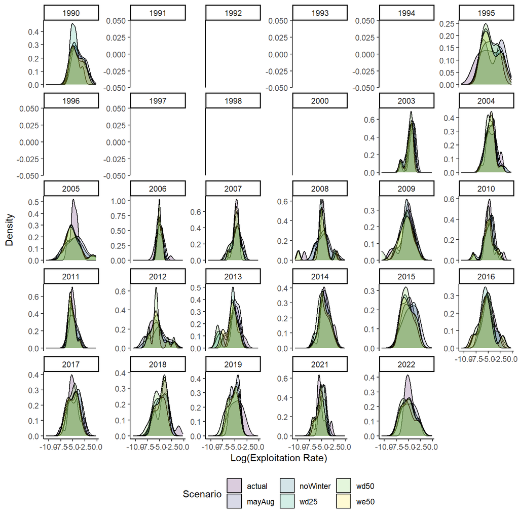

Figure 1.1: Distribution of exploitation rates across years in the creel data set. Different data reduction scenarios are noted with varying colors.

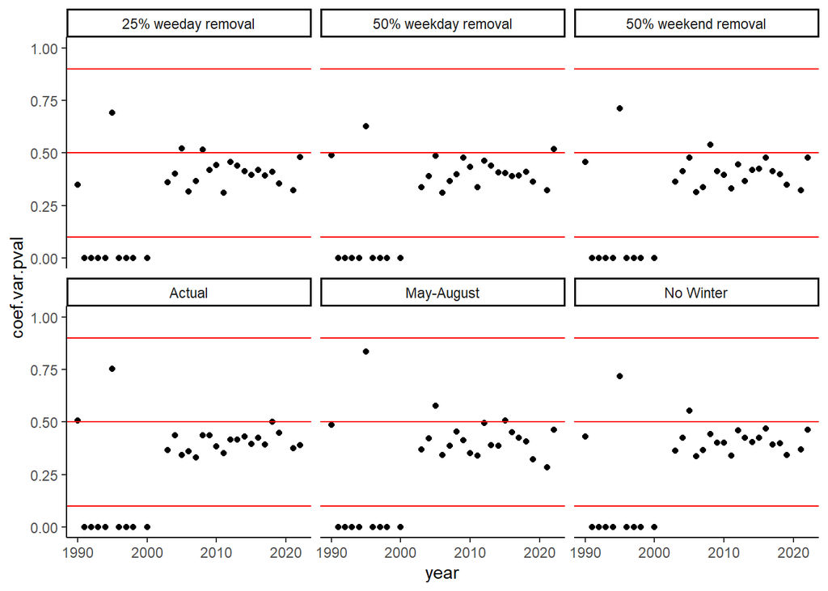

Comparison of coefficient of variations for bayesian p-values comparing the actual data to the simulated data for the creel year and data reduction scenario.

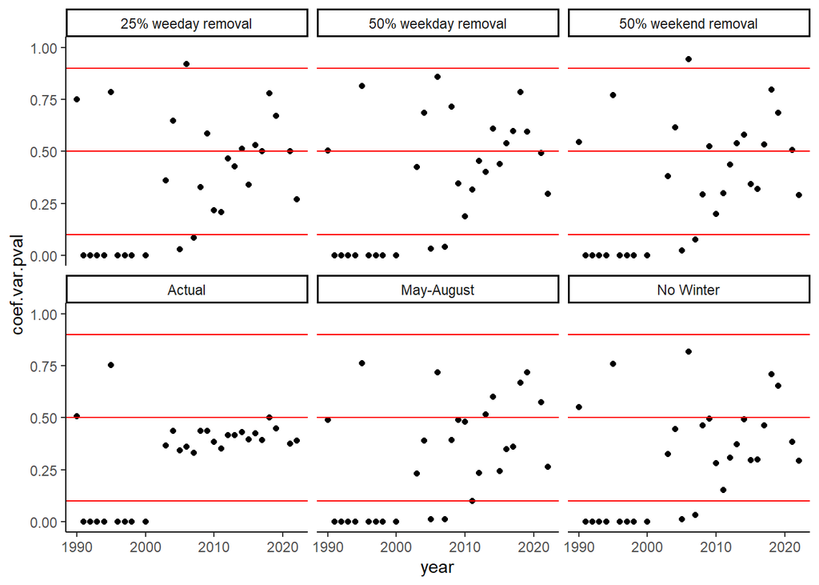

Comparison of the coeffienct of variations for bayesian p-values comparing the simulated data from each creel year and data reduction scenario to the actual data for that same creel year.

### 1.3.5 Important Caveats

Here are the important caveats for this analysis. These are things that I would expect another researcher to raise as potential weak points of this work. Numbers 1 and 2 can be addressed by me in consultation with other researchers and the scientific literature. Numbers 3 and 4 are more potentially informed by the legal context of the situation. These don’t have ‘right’ answers in the way that the other two do. Here the ‘right’ answer will be values-based and likely depends on what the group, or legal system, decides.

1. How to deal with exploitation rate estimates equal to 0. I have outlined my approach to this above and the rationale behind it, but that doesn’t mean someone else might not pick at that and say it’s a flaw. One way to address this would probably be to model the data using a beta or gamma distribution instead of a lognormal distribution. This would allow the 0s to be included.
2. Accuracy measure. In order to compare the exploitation rate estimates from the reduced data to the actual data I used 1 standard deviation as my measure. This means that a reduced-data exploitation rate estimate that is within 1 SD of the actual data exploitation rate estimate was considered to be ‘the same’. There may be better metrics to use here, and different people may have different opinions about the best metric to use. My rationale for using this metric has been outlined above.
3. Bayesian p-value metrics. when calculating the Bayesian p-value to understand if the data from the reduced scenarios resembled that of the actual data I used the coefficient of variation and standard deviation. In reality any variance metric could be used to compare the two data sets. I chose these two because I felt that were intuitive enough for anyone to understand and defensible. But that may be others that should be explored and the results of the p-value tests may differ based on the metric used.
4. Related to the p-value metric are the cutoffs to use to decide whether there is a meaningful difference between the actual exploitation rate and the data reduced rate. The rule of thumb for this test is values <0.1 or >0.9 indicate a significant difference between the actual data estimate and the reduced data estimate. In reality it is up to the user to decide what those cutoffs should be based on the context of their problem. Whether or not we consider the reduced data exploitation rates similar or different from the actual can obviously be influenced by the cutoff numbers we chose.